# Predict MDR-TB

Alyssa Santoso

2023-12-27

```r
library(readxl)
library(dplyr)
library(writexl)
library(moments)
library(psych)
library(car)
```

```r
library(ggplot2)
library(ISLR2)
library(randomForest)
library(caret)
library(gbm)
library(purrr)
moldova <- read_excel("/Users/maddysantoso/Downloads/Moldova_data.xlsx",  col_names = TRUE)
```

Some data cleaning and variable selection. Variables chosen to use: Continuous Data: household_size, age_at_diagnosis Categorical Data: prev_treatment, location, HIV_test , citizenship, Gender_P6, ocupation_P9, salary_P9_a, type_TB Outcome variable: resistant (yes/no)

```r
# Make variable resistant= yes/no (1/0)
moldova$resistant <- ifelse(moldova$P21_H == TRUE & moldova$P21_R == TRUE, "Yes", "No")
moldova$resistant <- factor(moldova$resistant, levels = c("Yes", "No"))

# Make variable prev_treatment= Yes/No using P23
moldova$prev_treatment <- ifelse(moldova$P23 == 2, "No", "Yes")
moldova$prev_treatment <- factor(moldova$prev_treatment, levels = c("Yes", "No"))

#rename urban-rural_P5_c
moldova <- moldova %>%
  rename(location = `urban-rural_P5_c`)

#rename p24
moldova <- moldova %>%
  rename(type_TB = P24)

#rename p13
moldova <- moldova %>%
  rename(household_size = P13)


# Make variable HIV_test= Positive/Negative/Unknown
moldova$HIV_test <- ifelse(moldova$aP28 == 2, "Positive",
                           ifelse(moldova$aP28 == 3, "Negative", "Unknown"))

#age_at_diagnosis variable
moldova <- moldova %>%
  mutate(age_at_diagnosis = as.numeric(difftime(P14, birth_day, units = "days")) / 365.25)

selected_variables <- c("household_size", "age_at_diagnosis", "resistant", "prev_treatment", "location", "HIV_test",
                        "citizenship", "Gender_P6", "ocupation_P9", "salary_P9_a", "type_TB")
moldova2 <- subset(moldova, select=selected_variables)
moldova2 <- na.omit(moldova2) # omit NA rows
```

Exploratory Data Analysis to further understand the dataset. For continuous variables, I will check the distribution, normality and outliers. For categorical and discrete variables, I examined frequency using tables and bar charts. Furthermore, I performed a chi-squared analysis to test associations for each pair of categorical variables, and to aid in variable selection.

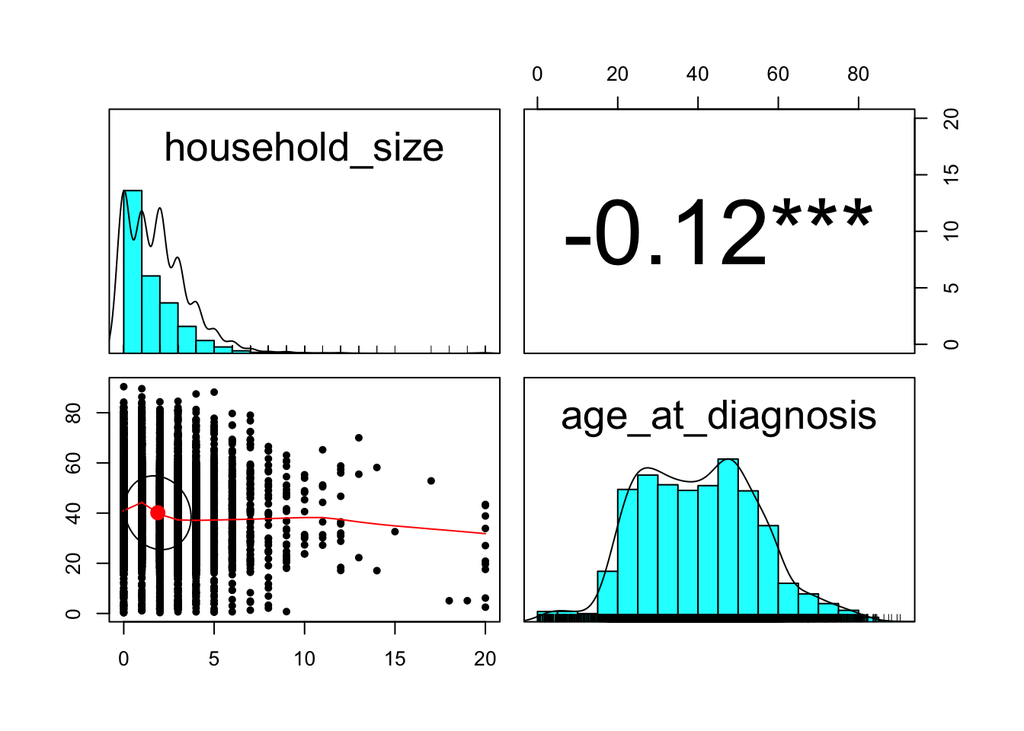

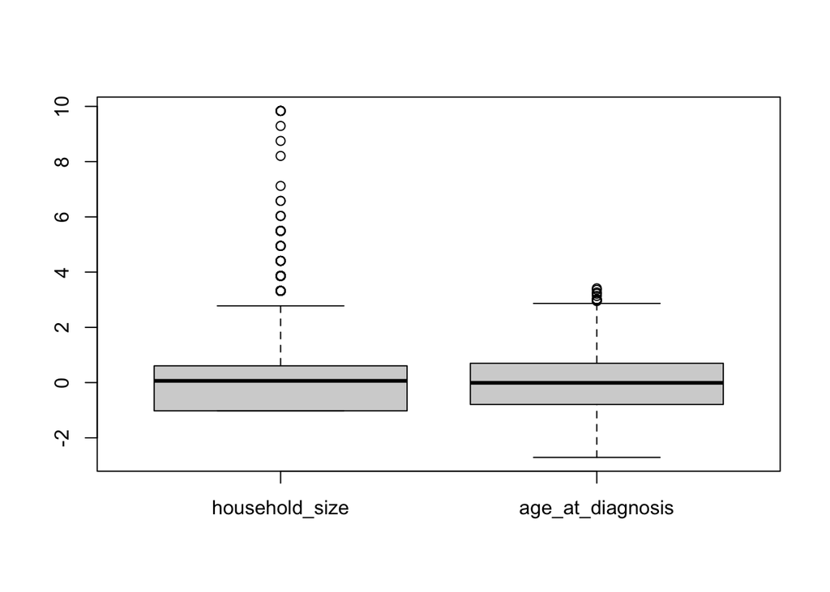

```
##   household_size age_at_diagnosis
##        2.1392750        0.1685133
```

```
## $resistant
##
##  Yes   No
## 1694 9807
##
## $prev_treatment
##
##  Yes   No
## 3585 7916
##
## $location
##
## rural urban
##  6080  5421
##
## $HIV_test
##
## Negative Positive  Unknown
##     8425      540     2536
##
## $citizenship
##
## Moldova   other
##   11450      51
##
## $Gender_P6
##
##    F    M
## 3004 8497
##
## $ocupation_P9
##
##   disabled  pensioner    student unemployed     worker
##       1021        818        507       7222       1933
##
## $salary_P9_a
##
##    N    Y
## 7963 3538
##
## $type_TB
##
##    1    2    3    4    5    6   21   22
## 7817  907  846  649  170   63  964   85
```

```
## $resistant
##
##      Yes       No
## 14.72915 85.27085
##
## $prev_treatment
##
##     Yes      No
## 31.1712 68.8288
##
## $location
##
##    rural    urban
## 52.86497 47.13503
##
## $HIV_test
##
##  Negative  Positive   Unknown
## 73.254500  4.695244 22.050256
##
## $citizenship
##
##    Moldova      other
## 99.5565603  0.4434397
##
## $Gender_P6
##
##        F        M
## 26.11947 73.88053
##
## $ocupation_P9
##
##   disabled  pensioner    student unemployed     worker
##   8.877489   7.112425   4.408312  62.794540  16.807234
##
## $salary_P9_a
##
##        N        Y
## 69.23746 30.76254
##
## $type_TB
##
##          1          2          3          4          5          6         21
## 67.9680028  7.8862708  7.3558821  5.6429876  1.4781323  0.5477785  8.3818798
##         22
##  0.7390662
```

```
##      [,1]
## [1,]  0.7
## [2,]  1.9
```

```
##      [,1]
## [1,]  0.7
## [2,]  1.9
```

```
##      [,1]
## [1,]  0.7
## [2,]  1.9
```

```
##      [,1]
## [1,]  0.7
## [2,]  1.9
## [3,]  3.1
```

```
##      [,1]
## [1,]  0.7
## [2,]  1.9
```

```
##      [,1]
## [1,]  0.7
## [2,]  1.9
```

```
##      [,1]
## [1,]  0.7
## [2,]  1.9
## [3,]  3.1
## [4,]  4.3
## [5,]  5.5
```

```
##      [,1]
## [1,]  0.7
## [2,]  1.9
```

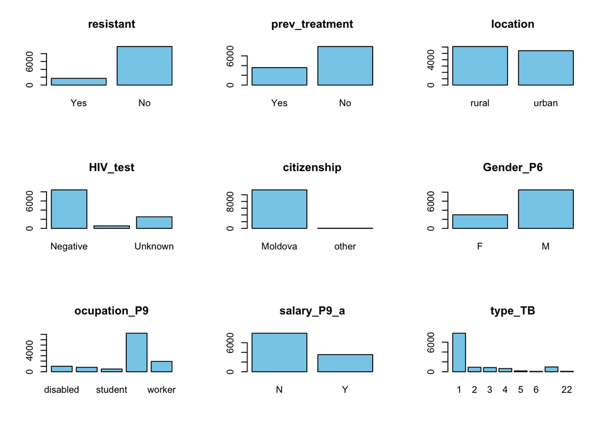